# Loading data from .csv files into RStudio

### The assignment operator “<-”

“<-” is called the “assignment operator”. It is a special type of R command.

“<” usually shares The comma key. Type “shift + ,” To get it.

If you type just “med98” and execute it as a command, what happens?

```r
med98
```

```
##   station  pH  DO cond temp alk hard   ZN spp.rich spp.div prop.Achnanthes
## 1     ERI 8.5 8.4  180   11 119  122    2     35.3    2.27            0.37
## 2     ER2 8.0 8.0  145   14  52   84  407     21.7    1.25            0.48
## 3     ER3 8.0 8.0  150   15  54   86  336     20.7    1.15            0.35
## 4     ER4 8.8 7.8  240   18  77  126  104     16.7    1.62            0.02
## 5     FC1 7.8 8.6   55    9  30   42    7     19.0    1.70            0.17
## 6     FC2 7.4 8.8  130    8  41   84 1735      5.7    0.63            0.76
```

You should see the entire dataset spit out in the console (I’ve just shown the top part).

Now execute the list command **ls()**. You should now see “med98” shown in the conosle.

```r
ls()
```

```
## [1] "med98"
```

This means that the **object** you assigned your data is now in your **“workspace.”** The workspace is what I call the working memory of R.

We can learn about the med98 data using command like dim(), names() and summary().

How big is the dataset overall?

```r
dim(med98)
```

```
## [1] 34 11
```

How man columns are there?

```r
names(med98)
```

```
##  [1] "station"         "pH"              "DO"
##  [4] "cond"            "temp"            "alk"
##  [7] "hard"            "ZN"              "spp.rich"
## [10] "spp.div"         "prop.Achnanthes"
```

Are any of the variables categorical?

```r
summary(med98)
```

```
##     station         pH              DO             cond
##  AR2    : 1   Min.   :6.700   Min.   :6.800   Min.   : 40.00
##  AR3    : 1   1st Qu.:7.425   1st Qu.:7.500   1st Qu.: 76.25
##  AR5    : 1   Median :7.900   Median :7.600   Median :100.00
##  AR8    : 1   Mean   :7.841   Mean   :7.794   Mean   :116.76
##  ARI    : 1   3rd Qu.:8.200   3rd Qu.:8.175   3rd Qu.:150.00
##  BR2    : 1   Max.   :8.800   Max.   :8.800   Max.   :240.00
##  (Other):28
##       temp            alk              hard              ZN
##  Min.   : 8.00   Min.   : 10.00   Min.   : 10.00   Min.   :   2.0
##  1st Qu.:11.00   1st Qu.: 28.50   1st Qu.: 45.00   1st Qu.:  24.0
##  Median :12.50   Median : 46.50   Median : 62.00   Median :  54.0
##  Mean   :13.06   Mean   : 46.38   Mean   : 66.76   Mean   : 177.3
##  3rd Qu.:15.00   3rd Qu.: 64.00   3rd Qu.: 90.50   3rd Qu.: 213.2
##  Max.   :21.00   Max.   :119.00   Max.   :126.00   Max.   :1735.0
##
##     spp.rich        spp.div      prop.Achnanthes
##  Min.   : 5.70   Min.   :0.630   Min.   :0.0200
##  1st Qu.:18.77   1st Qu.:1.377   1st Qu.:0.2125
##  Median :22.85   Median :1.855   Median :0.3900
##  Mean   :22.42   Mean   :1.694   Mean   :0.3756
##  3rd Qu.:26.82   3rd Qu.:2.058   3rd Qu.:0.4950
##  Max.   :42.00   Max.   :2.830   Max.   :0.7600
##
```

**OPTIONAL:**Plot the Mendley 1998 data

As we’ll discuss in depth in a later section on plotting , one reason why the **ggplot** and **ggpubr** packages are so powerful is because they can easily plot things in good color schemes. We can make a basic scatterplot like this to show the positive correlation between Diatom species richness (the raw number of species identified in a given sample) on the x axis and species diversity on the y axis.

First, load the ggpubr package using the library() command. Note that you might get some output in red text telling you about the packages; it looks scary but its not.

```r
library(ggpubr)
```

Now plot the scatter plot. Note that the syntax for ggpubr requires that variables be contained within quotes.

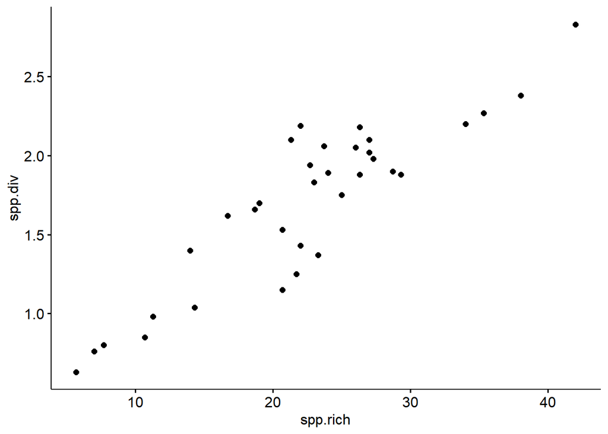

```r
ggscatter(data = med98, y = "spp.div",x = "spp.rich")
```

We can color-code the points by their pH

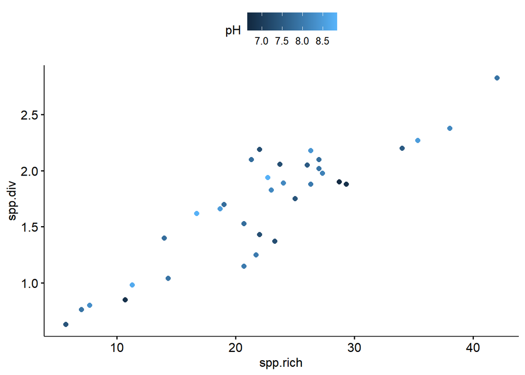

```r
ggscatter(data = med98, y = "spp.div",x = "spp.rich", color = "pH")
```

Frequently in code I will have things written up to load data using the **read.csv()** command. However, there is a point-and-click way of loading spreadsheet data into RStudio too.

There’s on pane in RStudio that doesn’t get used much by basic R users, the “Environmnet, History, Connections, Build, Git” pane (I think it might not have “Git” on it if you don’t have certain packages loaded).

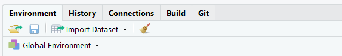

If you click on the spreadsheet-looking icon “Import Dataset” and select “From text (base)” you can navigate to where your .csv file is located and select it. A preview window will then pop up which will show you the raw (which should look like what you originally down loaded) and a preview of how RStudio will format the data. (If the preview doesn’t look right you can change some of the option in teh dropdown menus to see if things line up.)

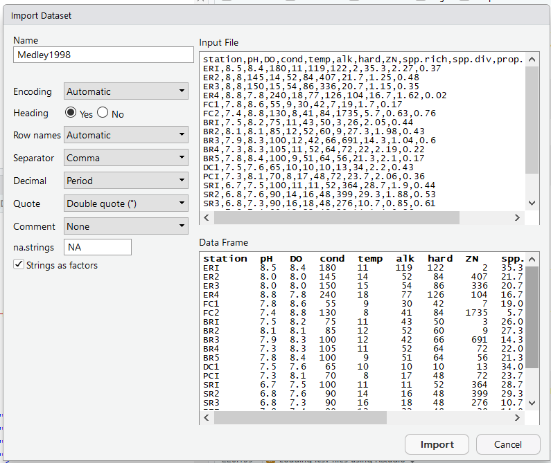

When you click “Import” RStudio will execute some code in the console (eg “Medley1998 <- read.csv(”~/Medley1998.csv“)”) to load the data and then call the command **View()** to generate preview of the data in a new tab in the script view. (Note that this View panel only lets you look at the data; you can’t edit it.)

## Challenge

.csv files are the most common format for sharing data in R. “csv” stands for “comma sperated volume”, and you will note that each value on a line is sperated by a comma (some thigns with computers do make sense on the firt try!).

Sometimes you will encounter .txt files which seperate data other ways, such as spaces, tabs, or by lining up everything explicitly in rows. On the wildlifeR GitHub directory we used before (https://github.com/brouwern/wildlifeR/tree/master/inst/extdata) these is a file “Medley1998.txt”. Download this file and load it using RStudios Import Dataset function. See if RStudio recognizes that its not .csv.